# `ggplot2` Exercises: Gapminder Data

Wed 10 Apr 2019 (14:44:32)

## Gapminder Data

We will use a subset of the gapminder data[^gapminder]. The variables in the dataset are as follows.

## Read in the data

```r
library(data.table)
library(here)
gm <- fread(here("data", "gapminder.csv"))

# Some modifications which will be useful later
gm[, continent:=as.factor(continent)]
gm[, country:=as.factor(country)]

gm
```

```
##       continent  country year population        gdp lifeexp infmort fertility
##    1:    Europe  Albania 1960    1636054         NA   62.87   115.4      6.19
##    2:    Europe  Albania 1965    1896125         NA   66.59    94.1      5.59
##    3:    Europe  Albania 1970    2150602         NA   67.83    76.8      5.05
##    4:    Europe  Albania 1975    2411229         NA   69.77    63.1      4.39
##    5:    Europe  Albania 1980    2681245 2833406779   71.39    64.0      3.68
##   ---
## 2216:    Africa Zimbabwe 1995   11683136 5967979333   56.00    60.1      4.43
## 2217:    Africa Zimbabwe 2000   12499981 6689957610   47.90    63.5      4.07
## 2218:    Africa Zimbabwe 2005   12984418 4557833784   45.10    61.0      3.97
## 2219:    Africa Zimbabwe 2010   13973897 4032423429   49.10    55.8      3.72
## 2220:    Africa Zimbabwe 2015   15602751         NA   59.30    46.6      3.35
```

```r
str(gm)
```

```
## Classes 'data.table' and 'data.frame':   2220 obs. of  8 variables:
##  $ continent : Factor w/ 5 levels "Africa","Americas",..: 4 4 4 4 4 4 4 4 4 4 ...
##  $ country   : Factor w/ 185 levels "Albania","Algeria",..: 1 1 1 1 1 1 1 1 1 1 ...
##  $ year      : int  1960 1965 1970 1975 1980 1985 1990 1995 2000 2005 ...
##  $ population: int  1636054 1896125 2150602 2411229 2681245 2966799 3281453 3106727 3121965 3082172 ...
##  $ gdp       : num  NA NA NA NA 2.83e+09 ...
##  $ lifeexp   : num  62.9 66.6 67.8 69.8 71.4 ...
##  $ infmort   : num  115.4 94.1 76.8 63.1 64 ...
##  $ fertility : num  6.19 5.59 5.05 4.39 3.68 3.23 2.97 2.72 2.38 1.92 ...
##  - attr(*, ".internal.selfref")=<externalptr>
```

## Life Expectancy - Portugal

Let’s plot life expectancy over time for Portugal.

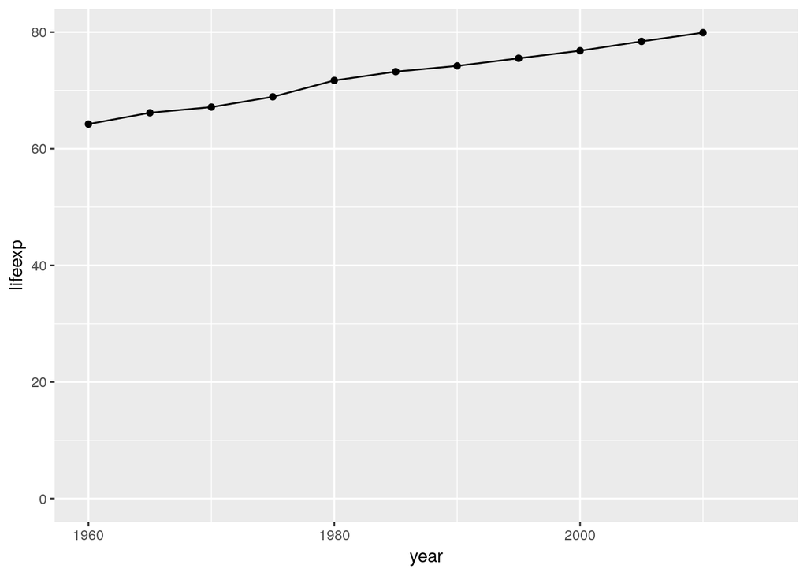

```r
library(ggplot2)
library(magrittr)

gm[country == "Portugal"] %>%
ggplot(aes(year, lifeexp)) +
  geom_point() +
  geom_line() +
  scale_y_continuous(
                limits=c(0, 80))
```

## Exercise 1: Portugal Questions

### Infant Mortality - Portugal

Plot the infant mortality rate over time for Portugal. Include the following:

- Colour for the lines and plots
- Labels for the axes.
- Add “Infant Mortality - Portugal” as a title (hint: use `ggtitle()`)

```r
# Type answer here.
```

**Interpret this plot.**

### Fertility Rate - Portugal

Plot the fertility rate over time for Portugal. Include the following:

- Colour for the lines and plots
- Labels for the axes.
- Add “Fertility Rate - Portugal” as a title (hint: use `ggtitle()`)

```r
# Type answer here.
```

Use the colours of the Portuguese flag,: “darkred” for points and “darkgreen” for lines. What do you notice when you switch the order of `geom_point()` and `geom_line()`? Do you strictly need to include the `geom_point()`?

**Interpret this plot.**

### Population & GDP

Produce the same plots for population and GDP. How do you interpret them both?